# Vizualizace dat a deskriptivní statistika

Podkladové čtenářské materiály k přednášce

Publikováno

26. února 2026

Upraveno

9. března 2026

## 1 Úvod

Tyto materiály slouží jako **textový doprovod k přednášce**. Přečtěte si je před přednáškou, aby vám základní pojmy nezněly cize, a vraťte se k nim po přednášce, když si budete chtít ujasnit jakýkoliv detail.

Po prostudování těchto materiálů budete schopni:

- Uložit naměřená data do vektoru v R a základně se v nich zorientovat.
- Zvolit vhodný graf pro jeden typ proměnné a vysvětlit, co graf ukazuje.
- Vypočítat a interpretovat základní deskriptivní statistiky (minimum, maximum, průměr, medián, kvartily, IQR, SD).
- Sestavit a přečíst krabicový graf (boxplot).
- Rozlišit typy proměnných a vybrat pro ně odpovídající popis i vizualizaci.

**PoznámkaJak číst kód v těchto materiálech**

Ukázky kódu v R jsou ve výchozím stavu **skryté**. Klikněte na tlačítko „Zobrazit kód v R” pro jejich rozbalení. Kód nemusíte hned spouštět — nejprve ho přečtěte a ujistěte se, že rozumíte, co dělá. Ke spuštění se vrátíte na cvičení.

## 2 Naše data — tučňáci z Palmer Station

Jako konkrétní datový příklad použijeme data z projektu **Palmer Penguins** — terénní studie ze tří ostrovů u Antarktidy (Biscoe, Dream, Torgersen). Vědci každoročně (2007–2009) počítali tučňáky tří druhů (*Adelie*, *Chinstrap*, *Gentoo*). Naší hlavní proměnnou bude **počet tučňáků zaznamenaných v jednom průzkumu** — jednoduché celé číslo, které ilustruje všechny statistické koncepty z kurzu.

### 2.1 Sběr dat krok za krokem

Podívejme se na první čtyři průzkumné záznamy:

[output not shown]

V R uložíme tato čtyři čísla do **vektoru** — jednoduché řady hodnot:

```r
pocet_tucnaku <-
  c(10L, 18L, 16L, 20L)

pocet_tucnaku
```

```
[1] 10 18 16 20
```

Jak přidáváme průzkumy, vektor se prodlužuje. My máme celkem **15 průzkumů** (kombinace třech druhů, tří ostrovů a tří let). V těchto materiálech budeme pracovat s vektorem `vzorek_poctu_tucnaku`, který tato data obsahuje. Kdykoli ho uvidíte, jde o naši sadu 15 hodnot.

### 2.2 Pohled na data

Než začneme počítat statistiky, podívejme se alespoň na prvních deset hodnot:

```r
length(vzorek_poctu_tucnaku)
```

```
[1] 15
```

```r
head(vzorek_poctu_tucnaku, n = 10)
```

```
 [1] 10 18 16 19 16 20 15 16 16 26
```

Vidíme různé hodnoty: 10, 18, 16, … I těch 15 čísel nám ale samo o sobě moc neřekne o tvaru distribuce. Proto **vizualizujeme**.

## 3 Vizualizace dat

### 3.1 Proč nejdřív vizualizovat?

Před tím, než spočítáme jakékoli číslo, bychom se na data měli *podívat*. To není jen zvyk — je to nutnost. Proč?

Mám dvě skupiny tučňáků. Obě mají průměrný počet **7**. Výpočty tedy říkají totéž:

```r
# Průměr skupiny A
mean(c(5, 6, 6, 7, 7, 7, 8, 8, 9))
```

```
[1] 7
```

```r
# Průměr skupiny B
mean(c(4, 4, 5, 5, 7, 9, 9, 10, 10))
```

```
[1] 7
```

Průměry jsou stejné. Ale podívejme se na distribuci hodnot:

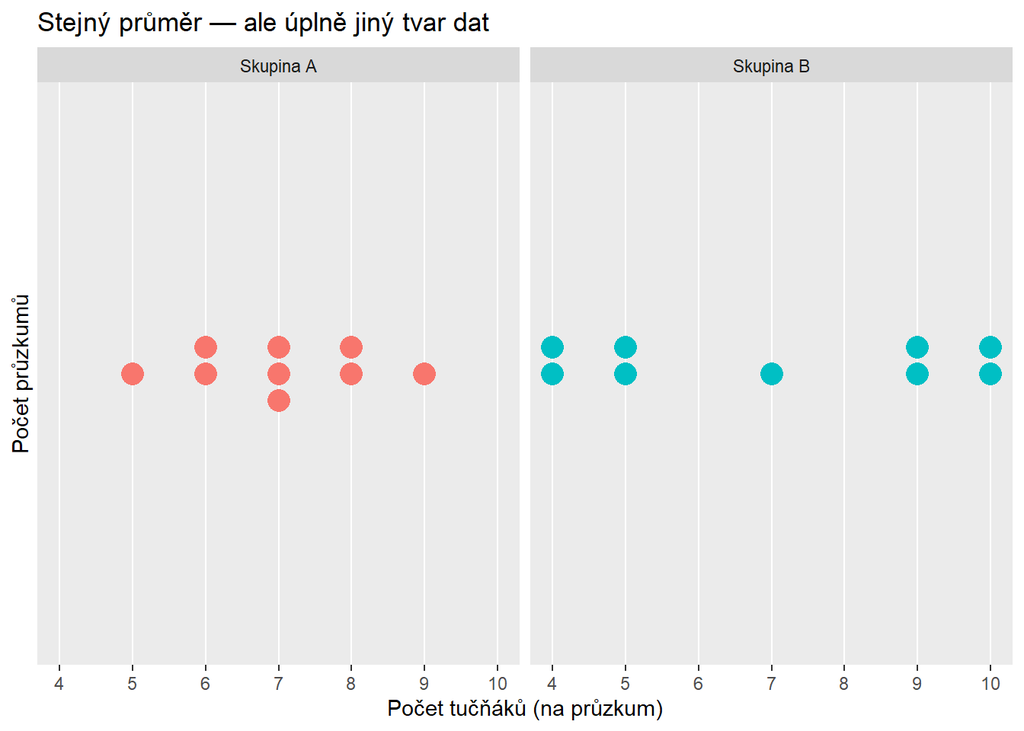

Skupina A má hodnoty soustředěné kolem 7 — data jsou symetrická, „hezká”. Skupina B má hodnoty spíše na okrajích — je buď malá, nebo velká, ale málokdy průměrná. To je zásadní biologický rozdíl, který číslo „průměr = 7” vůbec neodhalí.

**VarováníNikdy nepracujte jen s čísly bez grafu**

Čísla mohou klamat. Velmi odlišná data mohou mít stejný průměr i stejnou směrodatnou odchylku. Graf odhalí to, co čísla skrývají. Vždy nejdřív vizualizujte.

### 3.2 Bodový graf (beeswarm)

Nejpřímočařejší vizualizace: **každý bod = jeden průzkum**. Body jsou mírně rozptýleny do stran — technika se nazývá *beeswarm* (roj včel) — aby se vzájemně nepřekrývaly a zůstaly čitelné.

Co bodový graf ukazuje: vidíme **každou jednotlivou hodnotu**, tvar distribuce i případné odlehlé hodnoty.

**Graf**

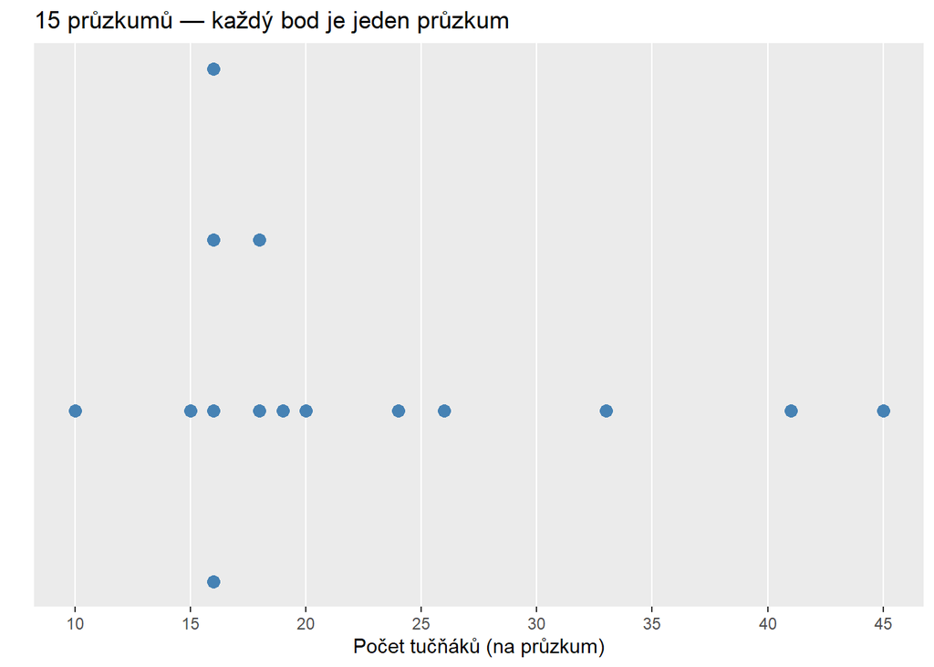

**Kód v R**

```r
# Jednoduchá alternativa v base R: stripchart
stripchart(
  x = vzorek_poctu_tucnaku,
  method = "jitter",
  pch = 19,
  col = "steelblue",
  xlab = "Počet tučňáků (na průzkum)",
  main = "Bodový graf"
)
```

### 3.3 Histogram

Histogram **seskupuje hodnoty do košů** (binů) a výška každého sloupce říká, kolik průzkumů do daného koše spadlo. Šířku koše (binwidth) si volíme sami.

Oproti bodovému grafu histogram nezobrazuje každý bod zvlášť — vidíme tvar distribuce, ale ztratíme přesné hodnoty jednotlivých průzkumů.

**Graf**

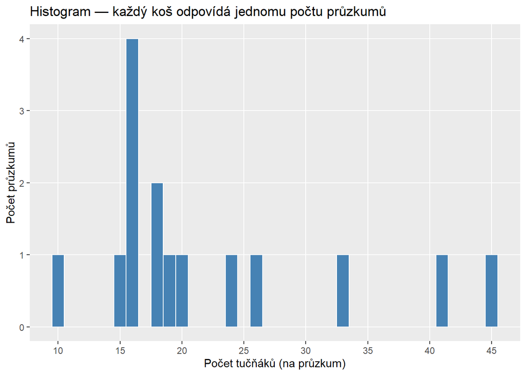

**Kód v R**

```r
hist(
  x = vzorek_poctu_tucnaku,
  breaks = seq(4.5, 49.5, by = 5),
  col = "steelblue",
  border = "white",
  xlab = "Počet tučňáků (na průzkum)",
  ylab = "Počet průzkumů",
  main = "Histogram"
)
```

**TipJak volit šířku koše?**

**Koš** (bin) je interval hodnot — například „od 14,5 do 19,5 tučňáků”. Každý průzkum spadne do právě jednoho koše a histogram zobrazí výšku sloupce rovnou počtu průzkumů v tom koši.

Šířka koše (`binwidth`) tedy říká, jak velký kus osy *x* jeden sloupec pokrývá. Volba šířky zásadně mění, co vidíte:

- **Příliš malá šířka** → každý koš obsahuje málo hodnot, graf je „zubatý”, šum překryje signál.
- **Příliš velká šířka** → spousta hodnot se sloučí do jednoho sloupce, přicházíme o detaily tvaru distribuce.

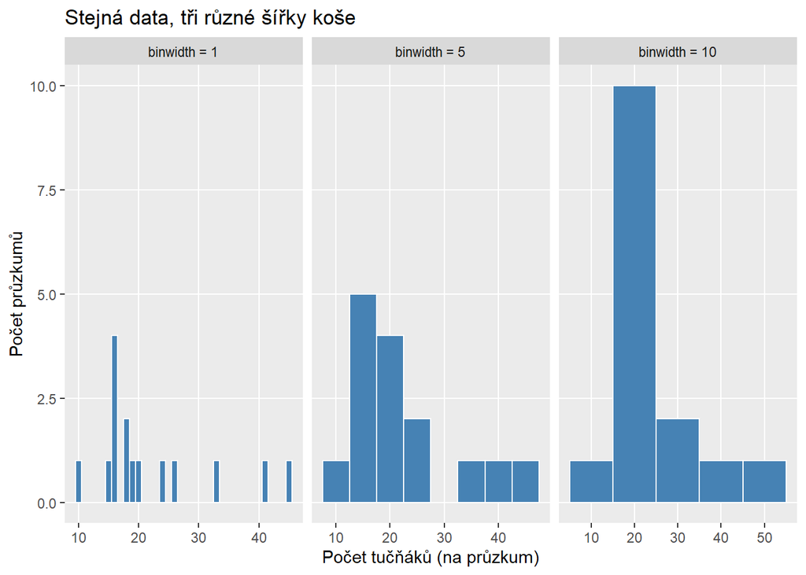

**Jak to konkrétně funguje?** Při `binwidth = 5` a středu koše na 20 zachytí koš všechny hodnoty od 17,5 do 22,5 — tedy průzkumy s asi 20 tučňáky. Při `binwidth = 10` by koš zachytil vše od 15 do 25 — sloučí dohromady průzkumy s 16, 18 i 20 tučňáky.

**Praktické doporučení:**

### 3.4 Graf hustoty

Graf hustoty je **vyhlazená verze histogramu**. Neukazuje absolutní počty, ale relativní hustotu — kde v osovém prostoru jsou hodnoty nejčastější. Osa y má jednotku „hustota” (density), nikoli „počet průzkumů”.

Prakticky vzato: špička grafu hustoty ukazuje, kde jsou data nejkoncentrovanější.

**Graf**

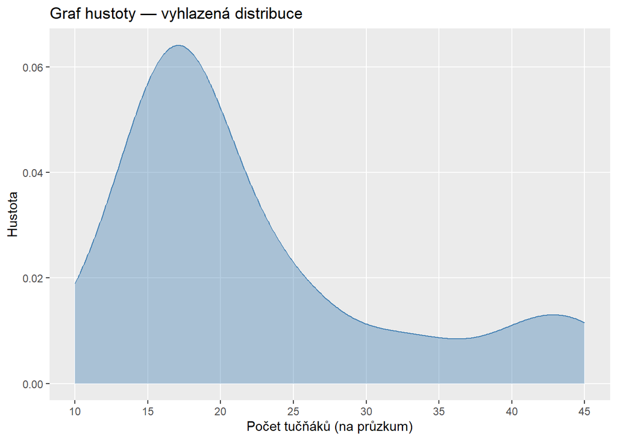

**Kód v R**

```r
hustota_tucnaku <-
  density(vzorek_poctu_tucnaku)

plot(
  hustota_tucnaku,
  xlab = "Počet tučňáků (na průzkum)",
  ylab = "Hustota",
  main = "Graf hustoty"
)
```

Všechny tři grafy — bodový, histogram i hustotní — ukazují tutéž věc z trochu jiné perspektivy. V praxi volte ten, který nejlépe komunikuje váš příběh. Bodový graf je nejupřímnější (vidíte vše), histogram je intuitivní pro počty, hustotní graf je nejhladší pro srovnání tvarů distribucí.

## 4 Deskriptivní statistiky

Grafy jsou skvělé pro pochopení dat, ale někdy potřebujeme jedno **číslo** — srovnatelné napříč skupinami, reportovatelné v tabulce. Deskriptivní statistiky nám říkají dvě věci: *kde leží střed dat* a *jak moc jsou data rozptýlená*.

Nejdřív si ukážeme výpočty **ručně na malém příkladu**. Použijeme devět průzkumných záznamů:

```r
maly_vzorek <-
  c(5L, 6L, 7L, 7L, 8L, 8L, 8L, 9L, 10L)
```

**PoznámkaProč píšeme `5L` místo `5`?**

Když napíšete v R prosté `5`, R ho uloží jako **desetinné číslo** (typ `double`, neboli `numeric`): interně je to `5.000000`. Přípona `L` říká R, že jde o **celé číslo** (typ `integer`): `5L` je přesně 5, bez desetinné části.

```r
typeof(5)    # "double"
typeof(5L)   # "integer"
```

Proč na tom záleží?

- **Počty tučňáků jsou vždy celá čísla** — průzkum nemůže zaznamenat 7,3 tučňáka. Označení `L` tuto skutečnost explicitně zakóduje do dat.
- **Paměťová úspornost**: `integer` zabírá v paměti přibližně polovinu oproti `double`.
- **Ochrana před překlepem**: R vás upozorní, pokud byste omylem přiřadili desetinnou hodnotu tam, kde je očekáváno celé číslo.

V praxi se `L` nejčastěji píše u indexů, počtů a jiných celočíselných konstant. Pro délku v mm nebo teplotu bychom `L` nepísali — tam se očekávají desetinná čísla.

Seřaďme je od nejmenšího po největší — to nám pomůže pochopit každou statistiku:

**5, 6, 7, 7, 8, 8, 8, 9, 10**

Kdykoli uvidíte `vzorek_poctu_tucnaku`, jde o plná data z 15 průzkumů.

### 4.1 Minimum a maximum

**Minimum** je nejmenší pozorovaná hodnota. **Maximum** je největší.

Z naší seřazené řady:

- Minimum: **5** — první (nejmenší) hodnota
- Maximum: **10** — poslední (největší) hodnota

Jsou to nejjednodušší statistiky, ale upozorní nás na případné extrémní hodnoty.

```r
min(maly_vzorek)
```

```
[1] 5
```

```r
max(maly_vzorek)
```

```
[1] 10
```

Na plných datech z 15 průzkumů:

```r
min(vzorek_poctu_tucnaku)
```

```
[1] 10
```

```r
max(vzorek_poctu_tucnaku)
```

```
[1] 45
```

**Minimum na grafu**

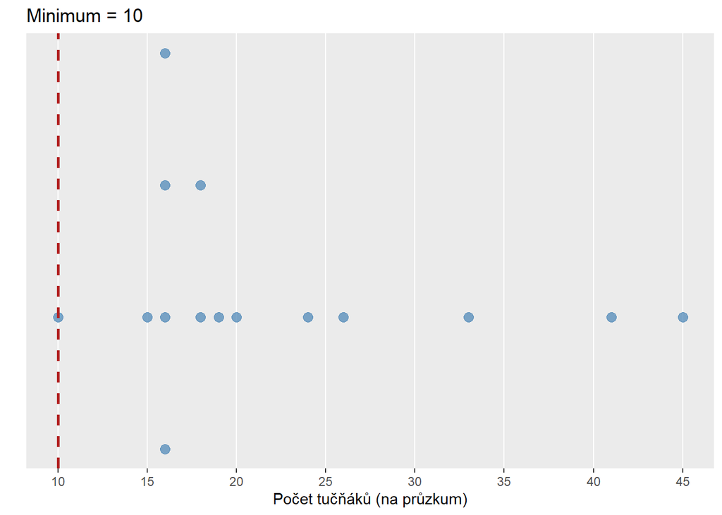

**Maximum na grafu**

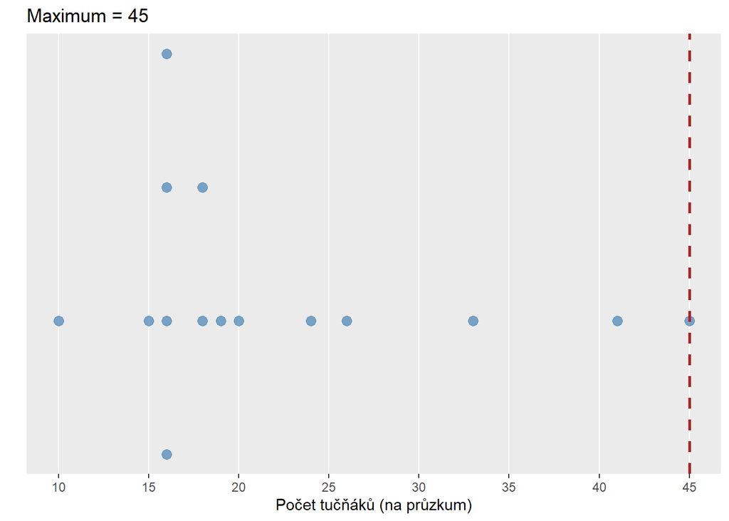

### 4.2 Percentily

Percentil je hodnota, pod níž leží určitý **podíl dat**. Pracujeme vždy se seřazenou řadou.

Ukažme si to na malém příkladu (5, 6, 7, 7, 8, 8, 8, 9, 10):

- **0. percentil (minimum):** 5 — pod touto hodnotou neleží žádný průzkumový záznam.
- **25. percentil (Q1, dolní kvartil):** R interpoluje a vrátí **7**.
- **50. percentil (medián):** Polovina dat leží pod, polovina nad. R vrátí **8**.
- **75. percentil (Q3, horní kvartil):** Tři čtvrtiny dat leží pod. R vrátí **8**.
- **100. percentil (maximum):** 10.

```r
quantile(
  x = maly_vzorek,
  probs = c(0, 0.25, 0.50, 0.75, 1)
)
```

```
  0%  25%  50%  75% 100%
   5    7    8    8   10
```

**PoznámkaProč percentily nevychází vždy „hezky”?**

Výpočet percentilů z malého vzorku vyžaduje interpolaci — odhadujeme polohu mezi hodnotami, které ve skutečnosti nemáme. Proto 25. percentil vychází 7, ačkoli v datech tato přesná hodnota nemusí být. S větším vzorkem vychází výsledky přirozeněji. R nabízí dokonce 9 různých metod výpočtu (`type = 1` až `9`) — výchozí je metoda 7.

### 4.3 Medián

Medián je **50. percentil** — hodnota, která rozděluje seřazená data přesně napůl.

**Číselný příklad.** Seřadíme 9 průzkumných záznamů. Prostřední pozice = (9 + 1) / 2 = **5**. Hodnota na 5. místě je 8.

**Čísla v rovnici** — všechny hodnoty seřazené, prostřední zvýrazněná:

$$5,\ 6,\ 7,\ 7,\ \boxed{8},\ 8,\ 8,\ 9,\ 10 \quad\Rightarrow\quad \tilde{x} = x_{\left(\frac{9+1}{2}\right)} = x_{(5)} = 8$$

**Obecný vzorec** (pro liché n):

$$\tilde{x} = x_{\left(\frac{n+1}{2}\right)}$$

Kdybychom měli sudé n (např. 8 záznamů), prostřední dvě pozice n/2 a n/2 + 1 by se zprůměrovaly:

$$\tilde{x} = \frac{x_{\left(\frac{n}{2}\right)} + x_{\left(\frac{n}{2}+1\right)}}{2}$$

```r
median(maly_vzorek)
```

```
[1] 8
```

Na plných datech:

```r
median(vzorek_poctu_tucnaku)
```

```
[1] 18
```

**Medián na grafu**

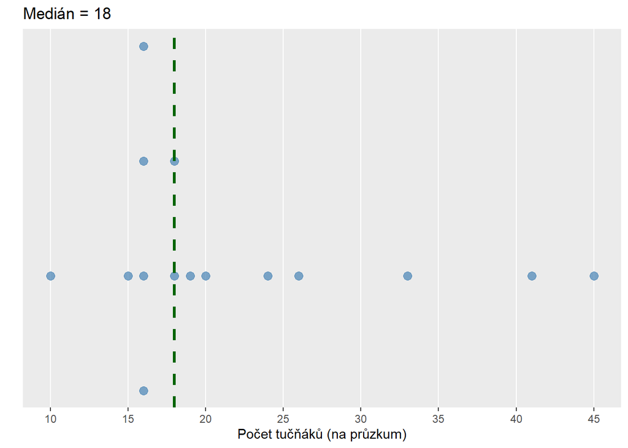

### 4.4 Mezikvartilové rozpětí (IQR)

Teď víme, kde leží **střed** dat. Ale jak moc jsou data **rozptýlená**?

Jednou z odpovědí je **mezikvartilové rozpětí** (IQR = interquartile range). Je to vzdálenost mezi horním a dolním kvartilem.

**Číselný příklad.** Z malého příkladu R vrátí Q1 = 7 a Q3 = 8. Vzdálenost = 8 − 7 = **1 průzkumných záznamů**.

**Čísla v rovnici:**

$$\text{IQR} = 8 - 7 = 1$$

**Obecný vzorec:**

$$\text{IQR} = Q_3 - Q_1$$

To znamená: prostřední polovina (50 %) průzkumů má počet tučňáků v rozmezí 7 až 8.

```r
quantile(maly_vzorek, 0.25)  # Q1
```

```
25%
  7
```

```r
quantile(maly_vzorek, 0.75)  # Q3
```

```
75%
  8
```

```r
IQR(maly_vzorek)             # Q3 - Q1
```

```
[1] 1
```

Na plných datech:

```r
quantile(vzorek_poctu_tucnaku, 0.25)  # Q1
```

```
25%
 16
```

```r
quantile(vzorek_poctu_tucnaku, 0.75)  # Q3
```

```
75%
 25
```

```r
IQR(vzorek_poctu_tucnaku)             # Q3 - Q1
```

```
[1] 9
```

**IQR na grafu**

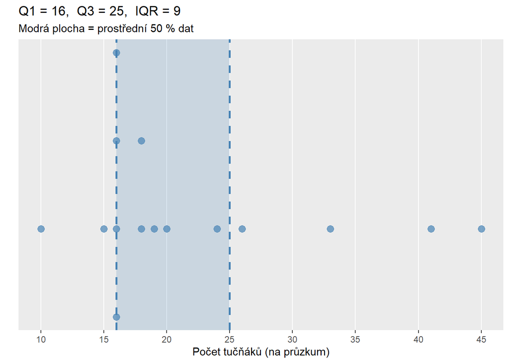

**TipKdy použít IQR místo SD?**

IQR je **odolné vůči odlehlým hodnotám** (outliers). Pokud máte data s extrémními hodnotami, nebo pokud jsou data výrazně asymetrická, IQR je bezpečnější volbou než směrodatná odchylka. Pro ordinální data (stupně poškození, škály souhlasu) je IQR prakticky jedinou smysluplnou mírou variability.

### 4.5 Průměr

Průměr (mean) je nejznámější statistika. Mechanicky: sečteme všechny hodnoty a vydělíme jejich počtem.

**Číselný příklad.** Sečteme všech 9 hodnot a vydělíme jejich počtem.

**Čísla v rovnici:**

$$\bar{x} = \frac{5 + 6 + 7 + 7 + 8 + 8 + 8 + 9 + 10}{9} = \frac{68}{9} = 7.56$$

**Obecný vzorec:**

$$\bar{x} = \frac{1}{n} \sum_{i=1}^{n} x_i$$

```r
# Ručně: součet děleno počet
sum(maly_vzorek) / length(maly_vzorek)
```

```
[1] 7.555556
```

```r
# Zkráceně pomocí funkce
mean(maly_vzorek)
```

```
[1] 7.555556
```

Na plných datech:

```r
round(
  mean(vzorek_poctu_tucnaku),
  digits = 2
)
```

```
[1] 22.2
```

**Průměr na grafu**

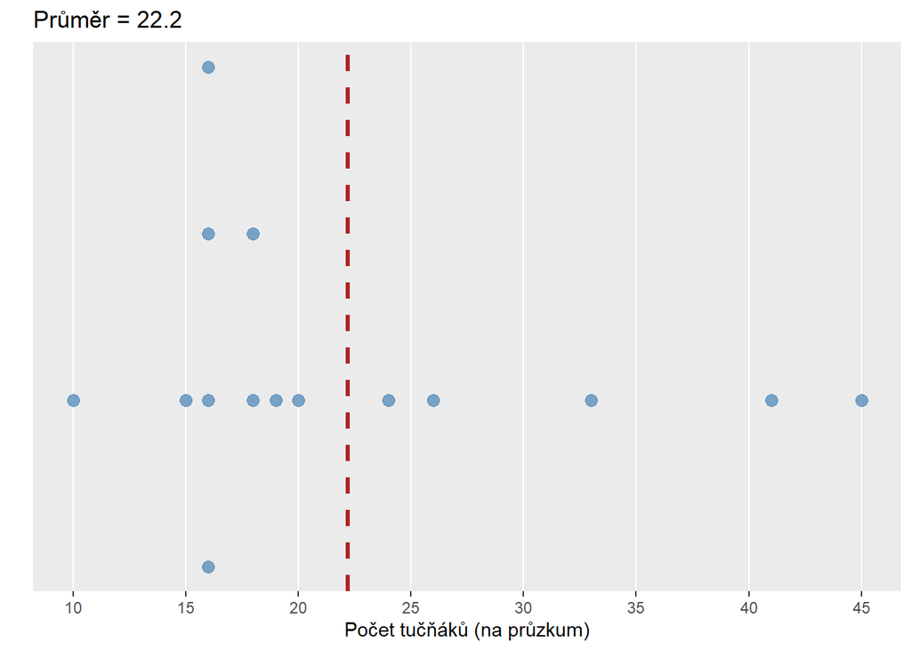

### 4.6 Průměr vs. medián — kdy záleží na rozdílu?

Průměr a medián měří „střed” dat různými způsoby. Většinou jsou si podobné — ale ne vždy. A ten rozdíl může být biologicky důležitý.

Představme si, že jsme registrovali **neobvykle velký průzkum s 90 tučňáky** — možná rozšíření sledované oblasti nebo výjimečně příznívá sežóna. Přidáme ho do dat:

```r
# Bez odlehlé hodnoty
mean(vzorek_poctu_tucnaku)
```

```
[1] 22.2
```

```r
median(vzorek_poctu_tucnaku)
```

```
[1] 18
```

```r
# S odlehlou hodnotou (90 tučňáků)
mean(pocet_tucnaku_outlier)
```

```
[1] 26.4375
```

```r
median(pocet_tucnaku_outlier)
```

```
[1] 18.5
```

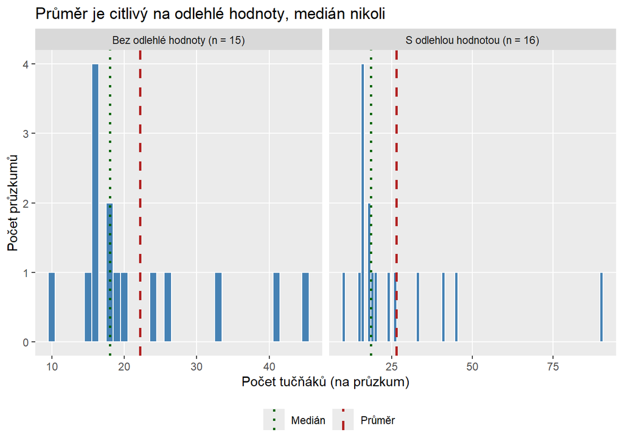

Průměr se posunul — jeden extrémní průzkum ho „přitáhl” ke své hodnotě. Medián se skoro nezměnil.

**VarováníPrůměr může být zavádějící**

Průměr je „přitahován” odlehlými hodnotami. V ekologii s nimi pracujeme neustále: počty druhů na lokalitách (jedna lokalita může být extrémně bohatá), velikosti těl v populaci, nebo množství srážek (jedno extrémní sucho nebo povodeň). Pokud máte podezření na odlehlé hodnoty nebo asymetrická data, preferujte **medián** jako míru středu.

**PoznámkaKdy je průměr lepší volbou?**

Průměr je také základní stavební kámen statistického modelování. Lineární model (`lm()`), který budeme používat po celý kurz, počítá průměry skupin a průměrné efekty prediktorů. Je tedy důležité chápat, kdy průměru věřit a kdy být obezřetní.

### 4.7 Rozptyl a směrodatná odchylka

Víme, kde leží střed dat. Teď chceme vědět, jak moc jsou data **rozptýlená kolem středu**.

Intuice: spočítejme, jak daleko je každá hodnota od průměru. Tuto vzdálenost nazýváme **odchylka** (residuum, chyba).

**Číselný příklad.** Průměr malého příkladu = 7.56. Pro první průzkumový záznam (hodnota 5): 5 − 7.56 = **-2.56**. Celý přehled pro všechny záznamy:

| Průzkum | Počet tučňáků | Průměr (x̄) | Odchylka (xᵢ − x̄) | Odchylka² |
| --- | --- | --- | --- | --- |
| 1 | 5 | 7.56 | -2.56 | 6.53 |
| 2 | 6 | 7.56 | -1.56 | 2.42 |
| 3 | 7 | 7.56 | -0.56 | 0.31 |
| 4 | 7 | 7.56 | -0.56 | 0.31 |
| 5 | 8 | 7.56 | 0.44 | 0.20 |
| 6 | 8 | 7.56 | 0.44 | 0.20 |
| 7 | 8 | 7.56 | 0.44 | 0.20 |
| 8 | 9 | 7.56 | 1.44 | 2.09 |
| 9 | 10 | 7.56 | 2.44 | 5.98 |

**Čísla v rovnici** (příklad pro první průzkumový záznam):

$$e_1 = 5 - 7.56 = -2.56$$

**Obecný vzorec:**

$$e_i = x_i - \bar{x}$$

Součet všech odchylek = 0 — záporné a kladné se vždy vyruší.

Jednoduché řešení by bylo vzít **absolutní hodnoty** odchylek (ignorovat znaménko) a ty sečíst. To skutečně dává smysluplné číslo zvané „průměrná absolutní odchylka”. Nicméně statistika tradičně volí jiný postup: odchylky **umocníme**. Proč?

1. **Zbavíme se znaménka**: $(-2{,}56)^2 = 6{,}55$ — záporné odchylky se stanou kladnými, stejně jako kladné.
2. **Velké odchylky jsou penalizovány víc**: Průzkum vzdálený 3 tučňáky od průměru přispívá $3^2 = 9$ do součtu. Tři průzkumy každý o 1 tučňáka vzdálené přispívají $3 \times 1^2 = 3$. Díky tomu SD „cítí” outlery a silně asymetrická data — stejnou vlastnost, za kterou jsme kritizovali průměr, ale tentokrát ji využijeme záměrně.
3. **Matematická pohodlnost**: Kvadrát je hladká funkce vhodná pro derivaci a optimalizaci — to se hodí v pokročilejší statistice.

**Součet čtverců odchylek** (anglicky *sum of squares*, zkratka SS) je tedy součet hodnot ze sloupce Odchylka² v tabulce.

**Čísla v rovnici:**

$$\begin{align}
\text{SS} &= (5-7.56)^2 + (6-7.56)^2 + (7-7.56)^2 + (7-7.56)^2 + (8-7.56)^2 + (8-7.56)^2 + (8-7.56)^2 + (9-7.56)^2 + (10-7.56)^2 \\
&= 6.53 + 2.42 + 0.31 + 0.31 + 0.2 + 0.2 + 0.2 + 2.09 + 5.98 \\
&= 18.22
\end{align}$$

**Obecný vzorec:**

$$\text{SS} = \sum_{i=1}^{n} (x_i - \bar{x})^2$$

**Číselný příklad.** Rozptyl = SS / (n − 1) = 18.22 / 8 = **2.28**.

**Čísla v rovnici:**

$$s^2 = \frac{6.53 + 2.42 + 0.31 + 0.31 + 0.2 + 0.2 + 0.2 + 2.09 + 5.98}{9 - 1} = \frac{18.22}{8} = 2.28$$

**Obecný vzorec:**

$$s^2 = \frac{1}{n-1} \sum_{i=1}^{n} (x_i - \bar{x})^2$$

*(Dělíme n − 1 místo n, protože odhadujeme rozptyl celé populace z vzorku. K tomu se vrátíme v přednášce o inferenci.)*

Ale rozptyl je v **kvadrátových jednotkách** — tučňáci², což je fyzikálně nesmyslné. Proto vezmeme odmocninu.

**Číselný příklad.** SD = √2.28 = **1.51 tučňáka**.

**Čísla v rovnici:**

$$s = \sqrt{\frac{18.22}{8}} = \sqrt{2.28} = 1.51$$

**Obecný vzorec:**

$$s = \sqrt{s^2}$$

To znamená: typický průzkumový záznam se od průměru odchyluje o přibližně 1.5 tučňáka.

```r
var(maly_vzorek)  # rozptyl (variance)
```

```
[1] 2.277778
```

```r
sd(maly_vzorek)   # směrodatná odchylka
```

```
[1] 1.509231
```

Na plných datech:

```r
round(sd(vzorek_poctu_tucnaku), digits = 2)
```

[output not shown]

Co toto číslo znamená **graficky**? Níže jsou dva pohledy:

- **Levý graf** zobrazuje průzkumy jako body. Červená přerušovaná čára je průměr, červené pásmo je rozsah průměr ± 1 SD. Zhruba dvě třetiny průzkumů leží uvnitř tohoto pásma — to je základní vlastnost dat blízkých normálnímu rozdělení.
- **Pravý graf** porovnává dvě skupiny se **stejným průměrem**, ale různou SD. Všimněte si, jak širší SD znamená roztáhlejší, plošší histogram.

**SD jako pásmo ±1 SD**

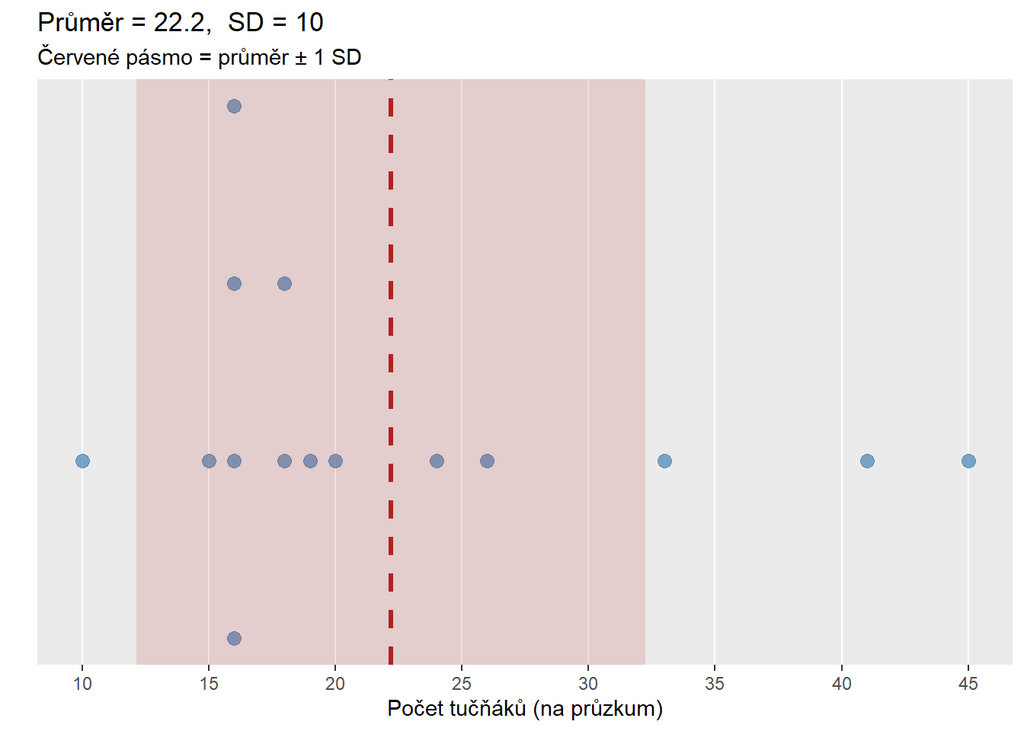

**Stejný průměr — různá SD**

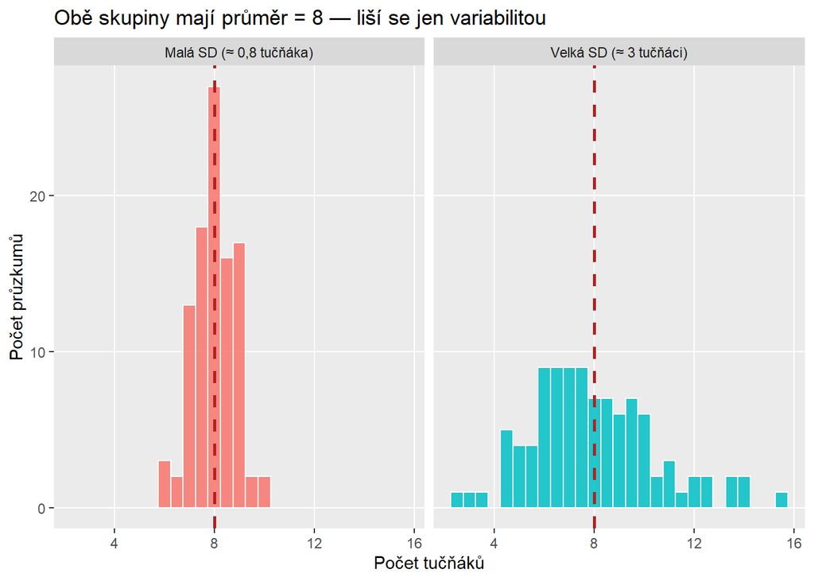

**PoznámkaCo SD znamená biologicky?**

Představte si dvě populace ptáků se stejnou průměrnou délkou křídla 20 cm. První populace má SD = 0,5 cm, druhá SD = 3 cm. První populace je velmi uniformní — možná žijí v homogenním prostředí pod silnou stabilizující selekcí. Druhá populace je variabilnější — možná jde o smíšenou populaci, nebo zažívají různorodé selekční tlaky.

SD tedy není jen „chyba měření” — obsahuje **biologickou informaci o variabilitě v populaci**. Menší SD neznamená „lepší data”, jen uniformnější populaci.

## 5 Statistiky jako vizualizace — krabicový graf

Všechny statistiky, které jsme spočítali (min, max, percentily, medián, IQR), lze nakreslit jako jeden přehledný graf: **krabicový graf** (boxplot). Pojďme ho sestavit krok za krokem, aby bylo jasné, co každý prvek znamená.

### 5.1 Krok 1: Medián

Začneme s tím, co již umíme — narýsujeme svislou čáru na pozici mediánu:

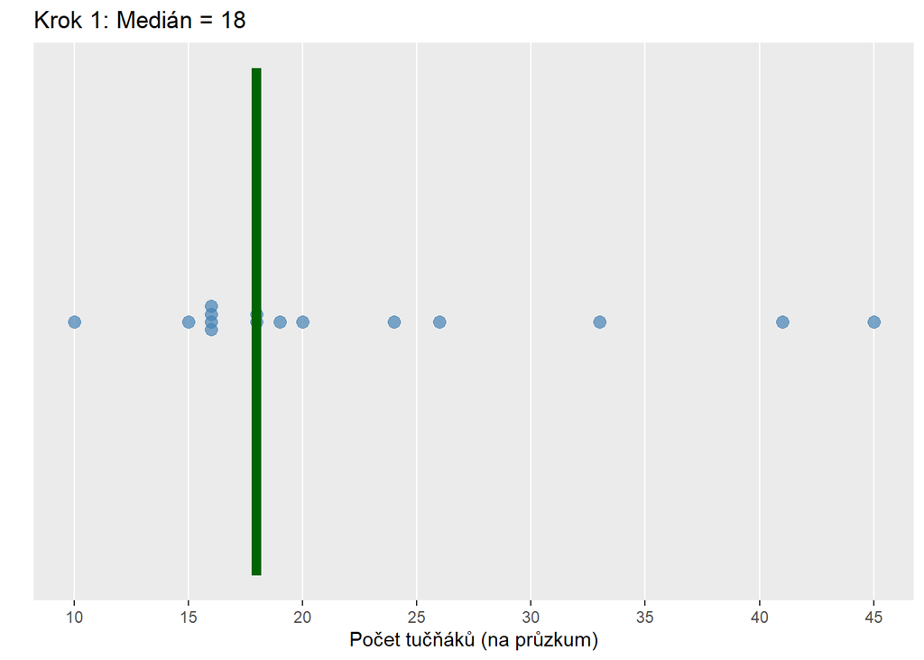

### 5.2 Krok 2: Krabice (IQR)

Přidáme obdélník od Q1 do Q3 — to je vlastní „krabice” (box):

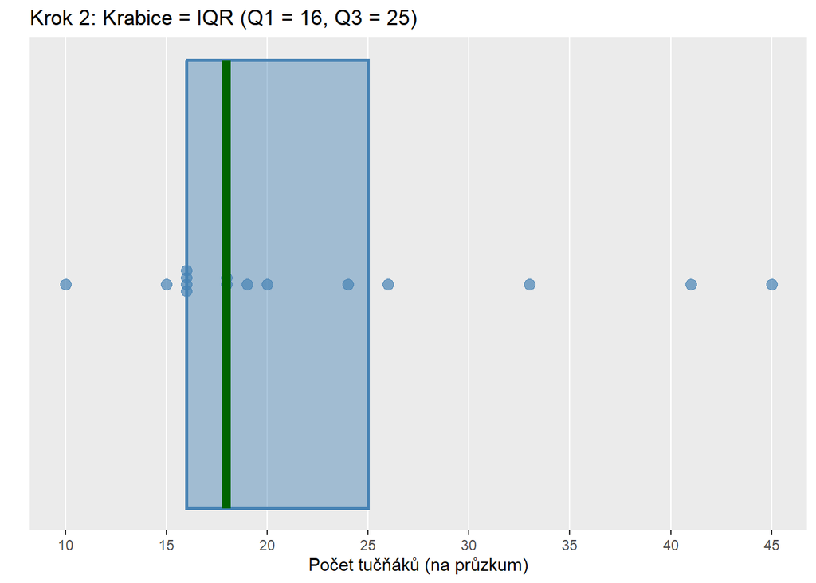

### 5.3 Krok 3: Vousy a odlehlé hodnoty

Vousy sahají od hran krabice maximálně o **1,5× IQR** dál. Body mimo vousy jsou **odlehlé hodnoty** — kreslí se jako separátní body:

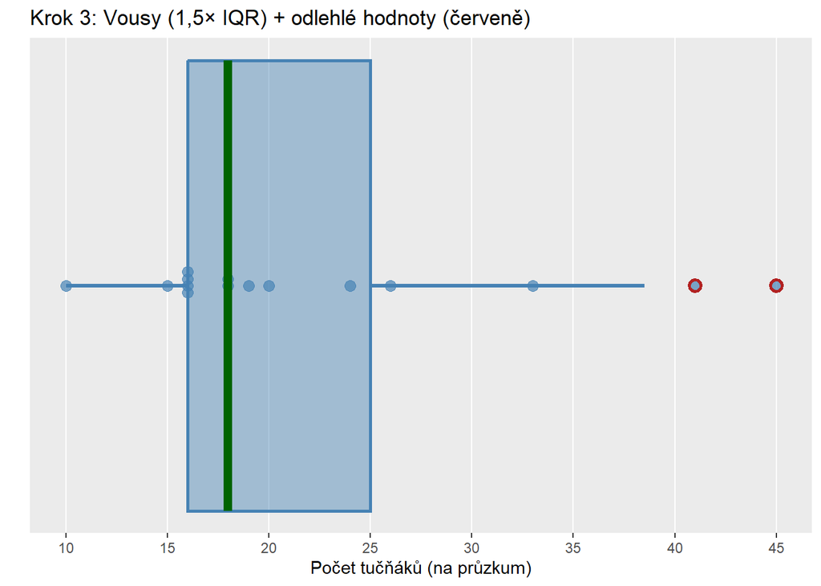

### 5.4 Výsledný krabicový graf

Takto vypadá výsledný boxplot, jak ho generuje R automaticky — tentýž tvar, jen nakreslený jedním příkazem:

**Boxplot**

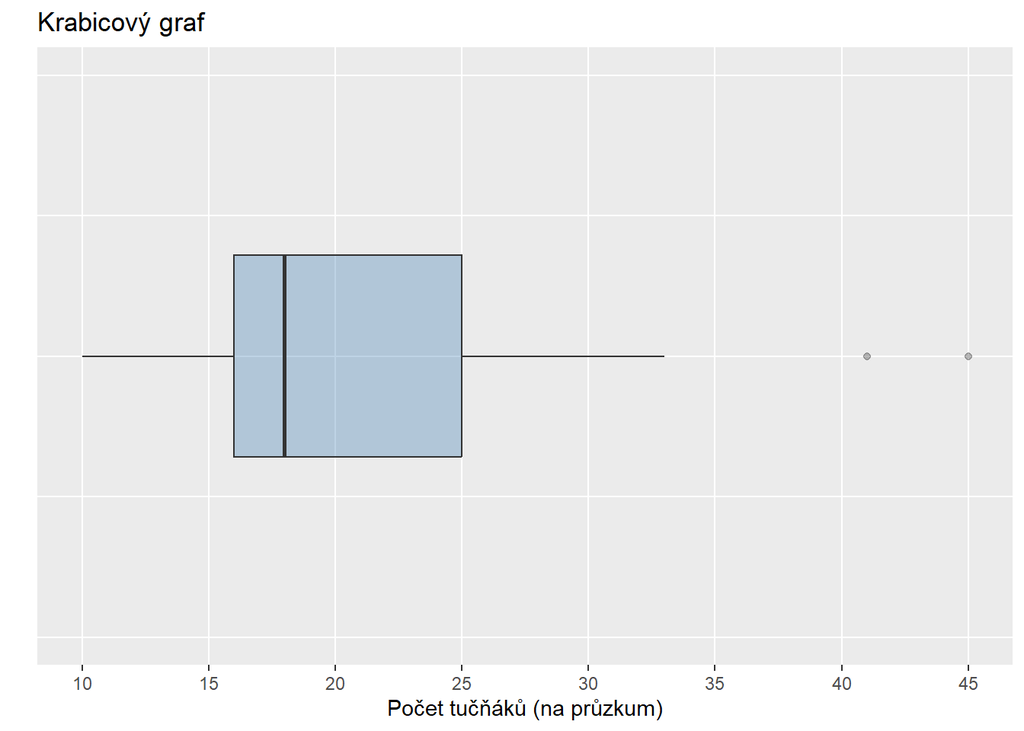

**Kód v R**

```r
boxplot(
  x = vzorek_poctu_tucnaku,
  horizontal = TRUE,
  col = "steelblue",
  xlab = "Počet tučňáků (na průzkum)",
  main = "Krabicový graf"
)
```

**Jak číst boxplot** — přehled prvků:

| Prvek | Co znamená |
| --- | --- |
| Tlustá čára uprostřed | Medián (50. percentil) |
| Krabice | Prostřední 50 % dat (Q1 až Q3, tedy IQR) |
| Vousy | Data do vzdálenosti 1,5× IQR od krabice |
| Osamělé body | Odlehlé hodnoty (přesahují vousy) |

**PoznámkaBoxplot je nejlepší graf pro srovnání skupin**

Zatímco histogramy a beeswarm grafy jsou skvělé pro zobrazení **jedné** distribuce, boxploty excelují, když chceme **porovnat více skupin** vedle sebe. Uvidíte to v dalších přednáškách — například když budeme srovnávat počty tučňáků na různých lokalitách nebo v různých letech.

## 6 Typy proměnných

Ne všechna data jsou čísla. A ne všechna čísla jsou si rovna. Typ proměnné určuje, jaký graf zvolíme, jakou statistiku spočítáme a jaký model použijeme.

### 6.1 Kvantitativní — diskrétní

Diskrétní proměnné nabývají pouze **celočíselných hodnot** — mezi nimi není žádná platná hodnota.

**Biologické příklady:**

- Počet tučňáků (na průzkum): 10, 18, 16, 20, …
- Počet druhů ptáků na lokalitě
- Počet vajec v hnízdě
- Počet jedinců v populaci

Nelze mít 7,3 tučňáka ani 4,7 vejce. Příroda „skáče” po celých číslech.

```r
pocet_tucnaku_ukazka <-
  c(10L, 18L, 16L, 20L)  # sufx L = celé číslo (integer)

class(pocet_tucnaku_ukazka)
```

```
[1] "integer"
```

**Vhodná vizualizace**

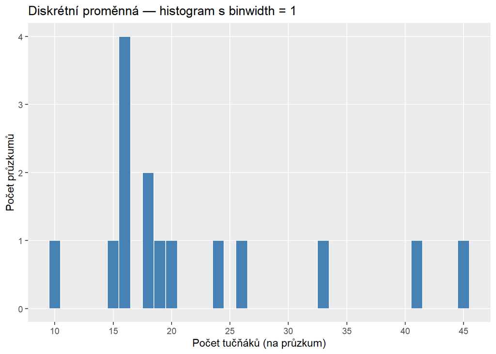

### 6.2 Kvantitativní — spojité

Spojité proměnné mohou nabývat **jakékoli hodnoty** v intervalu. Přesnost závisí jen na měřicím přístroji.

**Biologické příklady:**

- Délka zobáku v mm (39,1 mm, 40,3 mm, …)
- Teplota vzduchu
- Hmotnost živočicha
- Koncentrace chlorofylu v listu

```r
delka_zobaku_ukazka <-
  c(39.1, 40.3, 36.7, 42.9)  # desetinná čísla

class(delka_zobaku_ukazka)
```

```
[1] "numeric"
```

Pro spojitá data máme více vizualizačních možností — každá odhalí trochu jiný aspekt:

**Bodový graf**

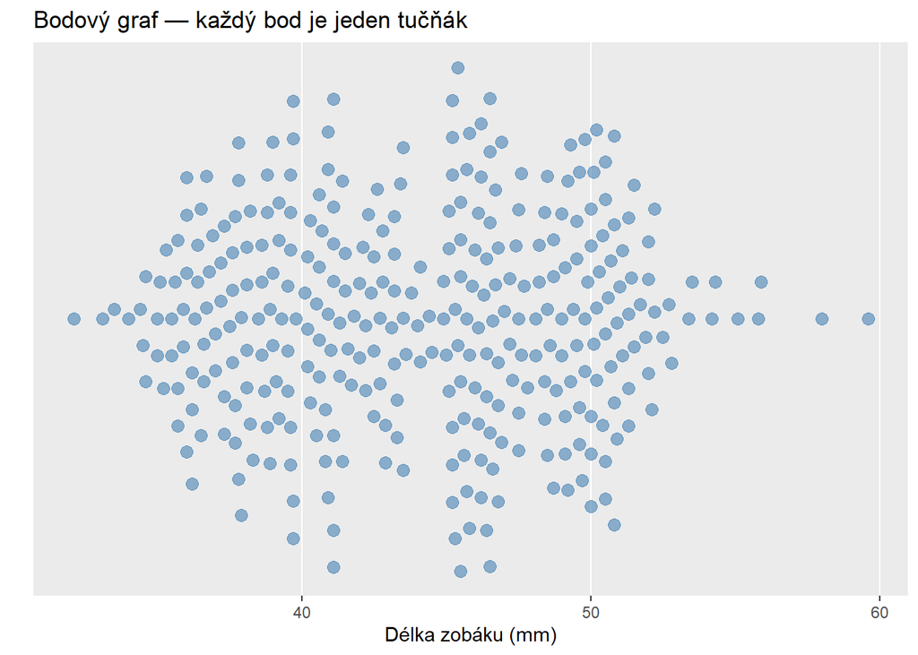

**Histogram**

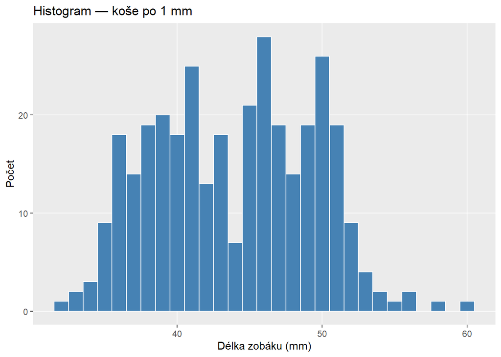

**Graf hustoty**

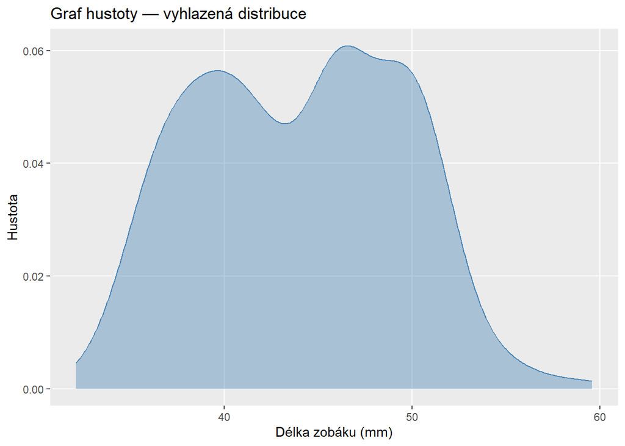

### 6.3 Kategorická — nominální

Nominální proměnné mají kategorie, **které nelze seřadit** — žádná není „větší” ani „lepší” než jiná.

**Biologické příklady:**

- Druh tučňáka (Adelie, Chinstrap, Gentoo)
- Druh opylovače (včela, čmelák, motýl)
- Typ stanoviště (les, louka, mokřad)
- Krevní skupina (A, B, AB, 0)

```r
druh_ukazka <-
  c("Adelie", "Chinstrap", "Adelie", "Gentoo")

class(druh_ukazka)
```

```
[1] "character"
```

Každá kategorie dostane vlastní barvu — vizuální kód, který odpovídá realitě:

**Sloupcový graf (počty)**

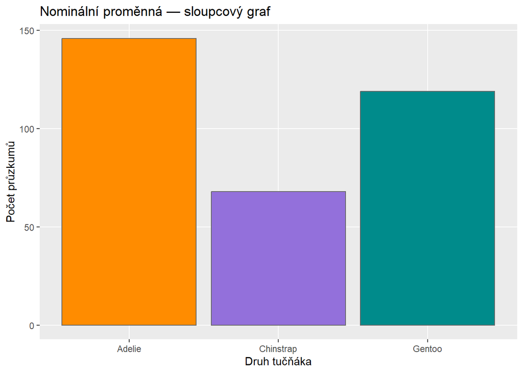

**Sloupcový graf (proporce)**

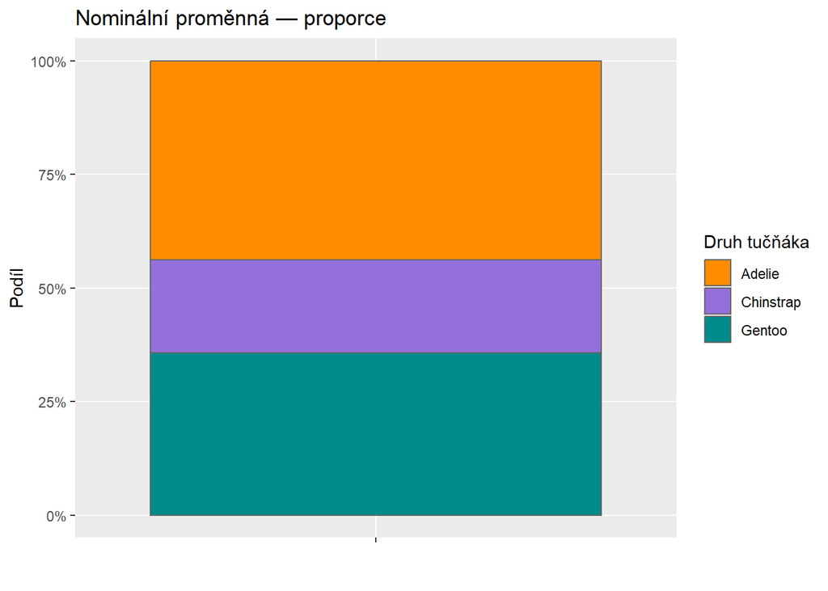

### 6.4 Kategorická — ordinální

Ordinální proměnné mají kategorie, **které jdou seřadit** — ale vzdálenosti mezi stupni nejsou nutně stejné.

**Biologické příklady:**

- Hmotnostní kategorie tučňáka (malý, střední, velký)
- Školní klasifikace (1, 2, 3, 4, 5)
- Souhlas s výrokem (zcela souhlasím → zcela nesouhlasím)
- Pokryvnost vegetace (0–5 %, 5–25 %, 25–50 %, …)

```r
# Klíčové: levels musí být seřazené!
hmotnost_ukazka <-
  factor(
    x = c("střední", "velký", "malý", "velký"),
    levels = c("malý", "střední", "velký"),
    ordered = TRUE
  )

hmotnost_ukazka
```

```
[1] střední velký   malý    velký
Levels: malý < střední < velký
```

R hlásí `Levels: malý < střední < velký` — znaménko `<` ukazuje pořadí.

**Vhodná vizualizace**

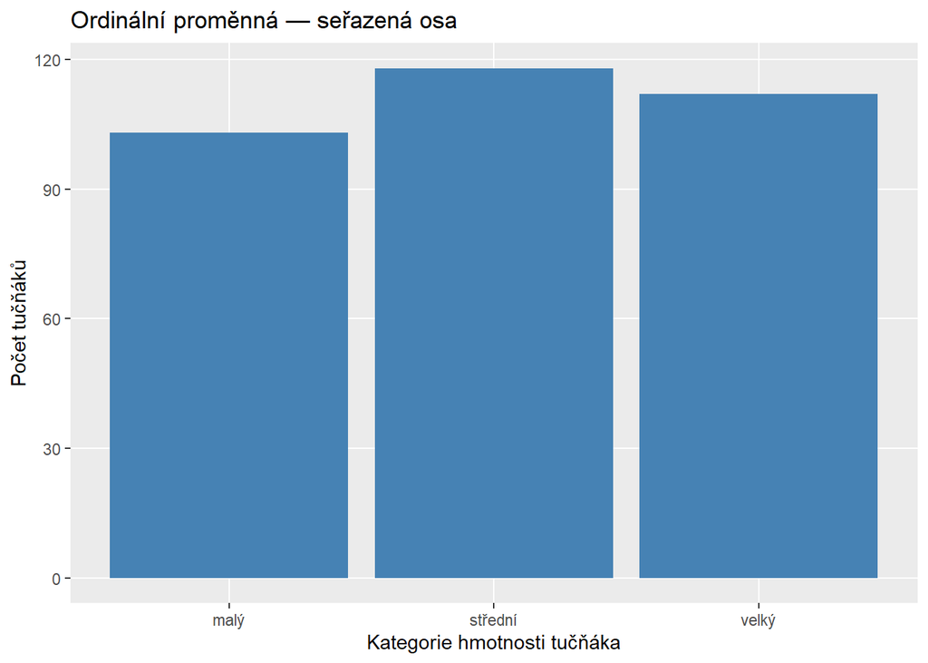

**DůležitéOrdinální data jako čísla — opatrně!**

Ordinální data jsou někdy zakódována jako čísla (1 = malý, 2 = střední, 3 = velký). Může být lákavé spočítat průměr a říci „průměrná kategorie = 1,7”. Ale to předpokládá, že rozdíl mezi „malým” a „středním” tučňákem je stejně velký jako mezi „středním” a „velkým” — a to nevíme. Pro ordinální data preferujte **medián a IQR**, nebo speciální ordinální modely.

### 6.5 Přehled typů proměnných

| Typ | Biologické příklady | Střed | Variabilita | Vhodný graf |
| --- | --- | --- | --- | --- |
| Kvant. diskrétní | počet tučňáků, počet druhů | průměr/medián | SD / IQR | histogram, beeswarm |
| Kvant. spojité | délka, teplota, hmotnost | průměr/medián | SD / IQR | histogram, boxplot, hustota |
| Kategorická nominální | barva, druh, typ stanoviště | modus | četnosti | sloupcový graf |
| Kategorická ordinální | hmotnostní kategorie, škála | medián | IQR | sloupcový graf (seřazený) |

**TipProč typ proměnné tak záleží?**

Typ proměnné určuje:

1. **Jaký graf** zvolíme — histogram pro čísla, sloupcový pro kategorie.
2. **Jakou statistiku** počítáme — průměr pro symetrická čísla, medián nebo modus pro ostatní.
3. **Jaký statistický model** použijeme — lineární model pro číselné odezvy, logistická regrese pro dichotomické kategorie, ordinální model pro seřazené kategorie.

Záměna typů proměnných je jedním z nejčastějších zdrojů chyb v analýze dat. Vždy si nejdřív ujasněte, co vlastně měříte.

*Materiály jsou průběžně aktualizovány. Datum poslední úpravy viz záhlaví.*